# Exercices Lecture 5

Paolo Crosetto

9/12/2019

# Intro

Jusque là on a utilisé R pour *manipuler* et representer graphiquement* des *jeux de données* (en langage R, des `data.frame`). Mais R est né et a été développé pincipalement comme un langage de *statistique*. Aujourd’hui on va donc s’occuper de cela: comment faire des statistiques simples (correlation, model linéaire, test statistique) avec R.

Pour chaque commande / outil statistique qu’on couvrira aujourd’hui, l’exposition va se diviser en deux parties:

1. **statistiques avec base R**. Pour faire des stats on va abandonner de façon temporaire le *tidyverse* et utiliser le système R de base. En soi cela ne vous changera pas grand chose, mais vous verrez que les résultats des différentes fonctions (tests, régressions, etc…) ne sont aps dans un format *tidy* – n’ont pas une variable par colonne et une observation par ligne – et ne sont donc pas prêts tout de suite à être utilisés avec ce qu’on a appris jusque là (filter, select, ggplot…).
2. **lien stats de base -> tidyverse**. Heureusement il y a des solutions. On va donc explorer le package `broom` qui permet de ‘faire le ménage’ (broom signifie *balai* en anglais) et de transofrmer les résultats des régressions en data.frames bien ordonnés, qu’on pourra utiliser pour, par exemple, visualiser les résultats de façon graphique. On pourra aussi utiliser la puissance du `%>%` et de `group_by()` pour mettre en place de façon rapide des analyses par groupe et les visualiser.

# Régression linéaire.

## Base R

> utilisez les données `airquality` – il s’agit de la qualité de l’air à NYC sur un certian interval de temps en 1973. estimez une régression linéaire qui explique le niveau d’Ozone par la température, le vent et la radiation solaire. sauvegardez le résultat de la régression dans un objet, `firstreg`.

```r
airquality
```

```
##     Ozone Solar.R Wind Temp Month Day
## 1      41     190  7.4   67     5   1
## 2      36     118  8.0   72     5   2
## 3      12     149 12.6   74     5   3
## 4      18     313 11.5   62     5   4
## 5      NA      NA 14.3   56     5   5
## 6      28      NA 14.9   66     5   6
## 7      23     299  8.6   65     5   7
## 8      19      99 13.8   59     5   8
## 9       8      19 20.1   61     5   9
## 10     NA     194  8.6   69     5  10
## 11      7      NA  6.9   74     5  11
## 12     16     256  9.7   69     5  12
## 13     11     290  9.2   66     5  13
## 14     14     274 10.9   68     5  14
```

[output cut: 139 more lines]

```r
firstreg <- lm(Ozone ~ Solar.R + Wind + Temp, data = airquality)
```

> explorez `firstreg` dans votre environnement. Il y a beaucoup de sous objets et sous parties. Essayez de visualiser le tableau récapitulatif. Utilisez `summary`

```r
summary(firstreg)
```

```
##
## Call:
## lm(formula = Ozone ~ Solar.R + Wind + Temp, data = airquality)
##
## Residuals:
##     Min      1Q  Median      3Q     Max
## -40.485 -14.219  -3.551  10.097  95.619
##
## Coefficients:
##              Estimate Std. Error t value Pr(>|t|)
## (Intercept) -64.34208   23.05472  -2.791  0.00623 **
## Solar.R       0.05982    0.02319   2.580  0.01124 *
## Wind         -3.33359    0.65441  -5.094 1.52e-06 ***
## Temp          1.65209    0.25353   6.516 2.42e-09 ***
## ---
## Signif. codes:  0 '***' 0.001 '**' 0.01 '*' 0.05 '.' 0.1 ' ' 1
##
## Residual standard error: 21.18 on 107 degrees of freedom
##   (42 observations deleted due to missingness)
## Multiple R-squared:  0.6059, Adjusted R-squared:  0.5948
## F-statistic: 54.83 on 3 and 107 DF,  p-value: < 2.2e-16
```

> il y d’autres sous objets que vous pouvez explorer. Si vous plottez l’objet, cela donne tous les diagnostics de régression (on ne rentre pas dans les détails ici). Notez que les plots ne sont aps des ggplots, mais ont un air très différents; il s’agit des plot produits par Base R.

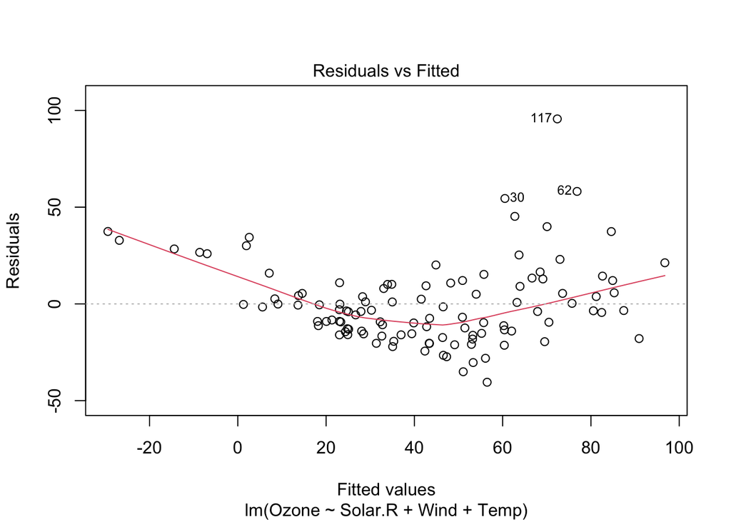

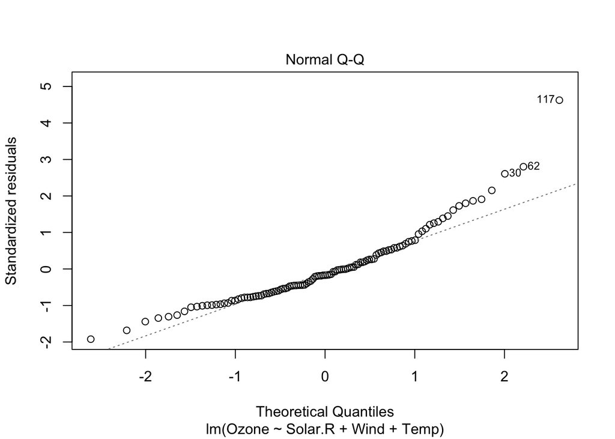

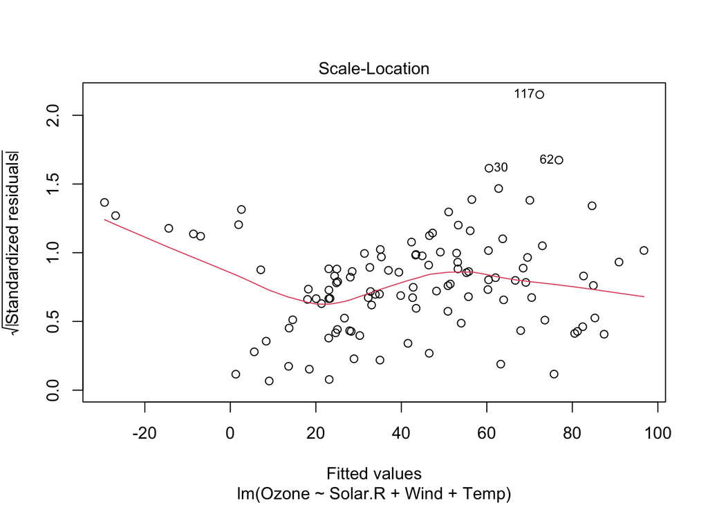

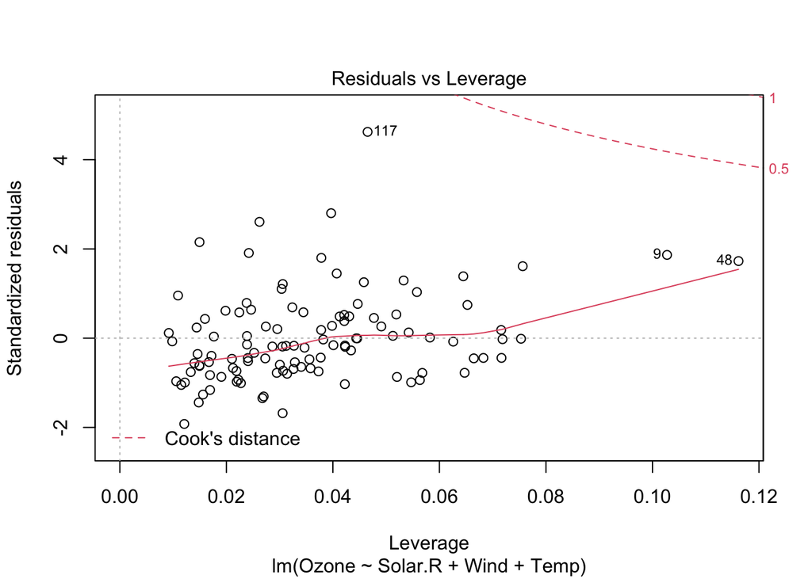

```r
plot(firstreg)
```

> vous pouvez accéder au coéfficients avec la fonction `coef()`

```r
coef(firstreg)
```

```
##  (Intercept)      Solar.R         Wind         Temp
## -64.34207893   0.05982059  -3.33359131   1.65209291
```

### exercice

> faites une régression de Ozone sur Wind en utilisant Base R et affichez son `summary()`

```r
lm(Ozone ~ Wind, data=airquality) %>%
summary()
```

```
##
## Call:
## lm(formula = Ozone ~ Wind, data = airquality)
##
## Residuals:
##     Min      1Q  Median      3Q     Max
## -51.572 -18.854  -4.868  15.234  90.000
##
## Coefficients:
##             Estimate Std. Error t value Pr(>|t|)
## (Intercept)  96.8729     7.2387   13.38  < 2e-16 ***
## Wind         -5.5509     0.6904   -8.04 9.27e-13 ***
## ---
## Signif. codes:  0 '***' 0.001 '**' 0.01 '*' 0.05 '.' 0.1 ' ' 1
##
## Residual standard error: 26.47 on 114 degrees of freedom
##   (37 observations deleted due to missingness)
## Multiple R-squared:  0.3619, Adjusted R-squared:  0.3563
## F-statistic: 64.64 on 1 and 114 DF,  p-value: 9.272e-13
```

## Broom

> tout cela n’est pas très pratique parce qu’on ne peut pas accéder aux données de la régression de façon *tidy*. On va donc utiliser `broom` pour le faire.

`broom` dispose de trois fonctions.

### tidy

voilà le output de `tidy`:

```r
lm(Ozone ~ Wind, data=airquality) %>%
  tidy()
```

```
## # A tibble: 2 x 5
##   term        estimate std.error statistic  p.value
##   <chr>          <dbl>     <dbl>     <dbl>    <dbl>
## 1 (Intercept)    96.9      7.24      13.4  3.99e-25
## 2 Wind           -5.55     0.690     -8.04 9.27e-13
```

> et voilà, nos résultats sont maintenant en forme de data.frame et peuvent donc être utilisés pour nos analyses, plots… notamment: faites un plot des coefficients de la régression avec des barres d’erreur

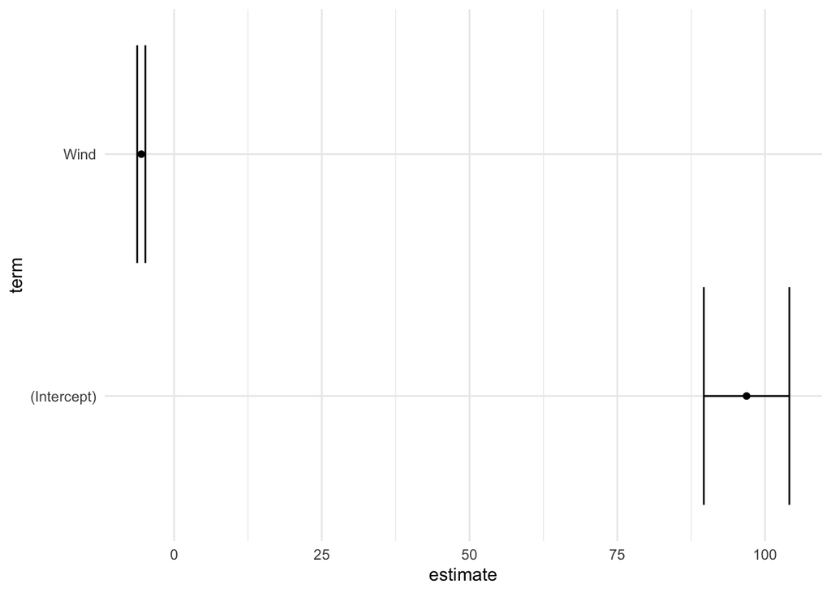

```r
lm(Ozone ~ Wind, data=airquality) %>%
  tidy() %>%
  ggplot(aes(y=term, x=estimate)) +
  geom_point() +
  geom_errorbar(aes(xmin= estimate-std.error, xmax = estimate+std.error, height = 0.1)) +
  theme_minimal()
```

> Faites une régression de Ozone sur Temp et Wind

```r
# strategie
# faire le lm()
lm(Ozone ~ Wind + Temp, data=airquality)
```

```
##
## Call:
## lm(formula = Ozone ~ Wind + Temp, data = airquality)
##
## Coefficients:
## (Intercept)         Wind         Temp
##     -71.033       -3.055        1.840
```

```r
# le passer par tidy()
lm(Ozone ~ Wind + Temp, data=airquality) %>%
  tidy()
```

```
## # A tibble: 3 x 5
##   term        estimate std.error statistic  p.value
##   <chr>          <dbl>     <dbl>     <dbl>    <dbl>
## 1 (Intercept)   -71.0     23.6       -3.01 3.20e- 3
## 2 Wind           -3.06     0.663     -4.61 1.08e- 5
## 3 Temp            1.84     0.250      7.36 3.15e-11
```

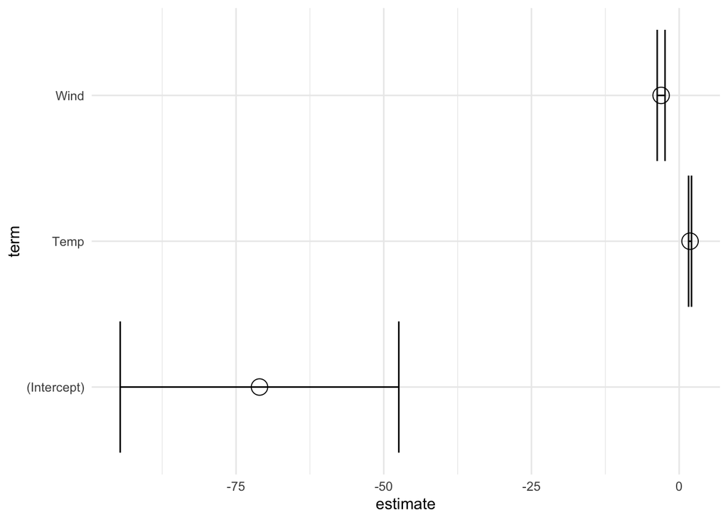

```r
# faire le plot
lm(Ozone ~ Wind + Temp, data=airquality) %>%
  tidy() %>%
  ggplot(aes(y=term, x=estimate)) +
  geom_point(size = 5, pch = 21) +
  geom_errorbar(aes(xmin = estimate - std.error, xmax = estimate + std.error, height = 0.1)) +
  theme_minimal()
```

### 2. augment

augment ajoute les valuers estimées à notre data.frame. Cela nous permet, par exemple, de voir la régression de façon visuelle (sur deux variables uniquement) en plottant les points intiaux et les points estimés. On va faire cela par étapes, et pour la rélation Ozone ~ Temp

### 1. les points originaux de la rélation Ozone ~ Temp

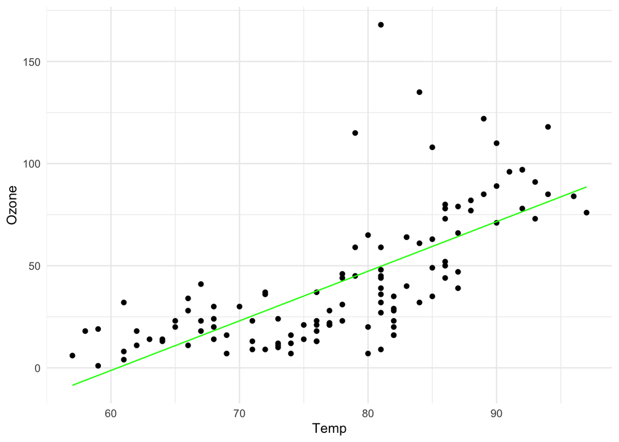

```r
lm(Ozone ~ Temp, data = airquality) %>%
  augment() %>%
  ggplot(aes(x = Temp,y = Ozone)) +
  geom_point() +
  geom_line(aes(x = Temp, y = .fitted), color = "green") +
  theme_minimal()
```

### 2. on ajoute les points estimés

(attention: ils seront sur une droite. Surpris?)

Vu qu’ils suivent une ligne droite, on peut aisément les plotter comme une `geom_line()`

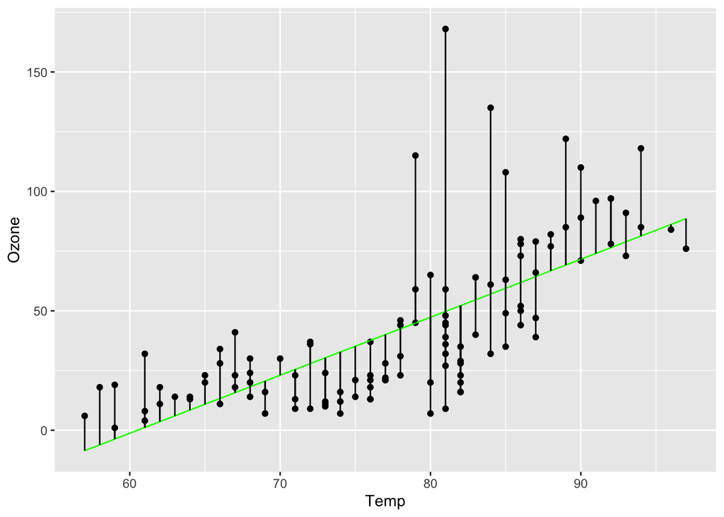

```r
lm(Ozone ~ Temp, data = airquality) %>%
  augment() %>%
  ggplot(aes(x = Temp,y = Ozone)) +
  geom_point() +
  geom_line(aes(x = Temp, y = .fitted), color = "green") +
  geom_segment(aes(x = Temp,xend = Temp,  y = .fitted, yend  = Ozone))
```

```r
  theme_minimal()
```

[output not shown]

[output cut: 329 more lines]

[output not shown]

Pour mieux visualiser les résidus on lie chaque point réel à sa prédiction par un `geom_segment()`

### exercice

> faites une régression de Ozone sur Wind en utilisant le tidyverse et `tidy`

### glance

glance est moins immédiatement utile mais le deviendra quand on pourra comparer différents modèles statistiques les uns à côté des autres. voilà ce que `glance()` donne

```r
lm (Ozone ~ Temp, data = airquality) %>%
  glance()
```

```
## # A tibble: 1 x 12
##   r.squared adj.r.squared sigma statistic  p.value    df logLik   AIC   BIC
##       <dbl>         <dbl> <dbl>     <dbl>    <dbl> <dbl>  <dbl> <dbl> <dbl>
## 1     0.488         0.483  23.7      109. 2.93e-18     1  -531. 1068. 1076.
## # … with 3 more variables: deviance <dbl>, df.residual <int>, nobs <int>
```

## La puissance du tidyverse: plusieurs régressions à la fois, par groupe

Avec le tidyverse on peut lancer plusieurs régressions à la fois, et en visualiser les résultats avec un seul ggplot. On va travailler avec la base de données `gapminder`.

### gapminder

gapminder est une base de données qui contient l’espérence de vie par pays sur plusieurs années. Il faut installer le package gapminder

```r
#install.packages(gapminder)
library(gapminder)
df <- gapminder
```

On va commencer par explorer les données. Comment l’espérance de vie a-t-elle évolué dans le temps pour tous les pays? un ggplot

```r
df %>%
  ggplot(aes(x = year, y = lifeExp, group = country)) +
  geom_line() -> spaghetti
```

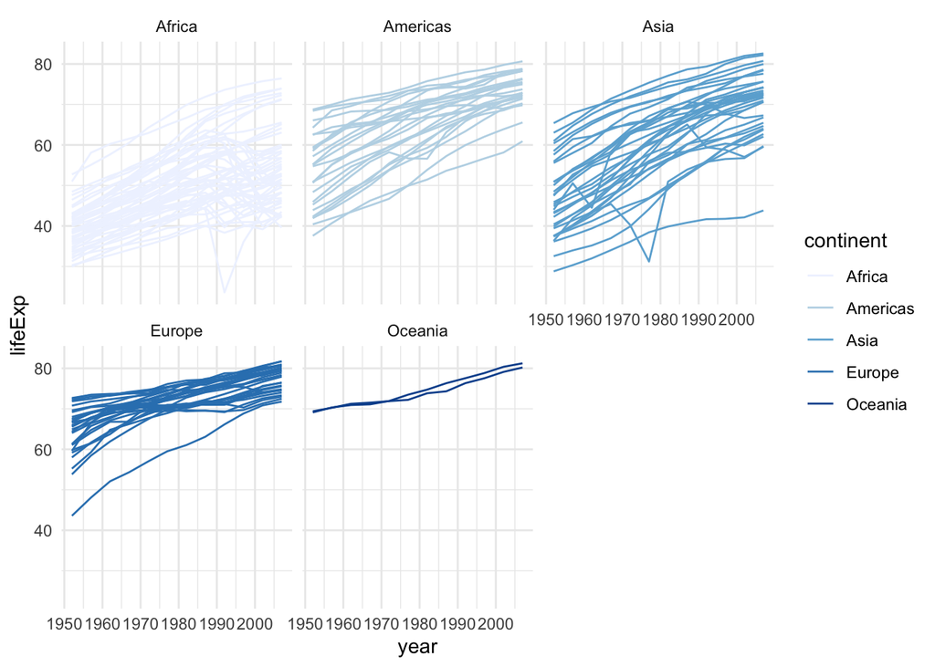

```r
spaghetti +
  facet_wrap(~continent) +
  aes(color = continent) +
  theme_minimal() +
  scale_colour_brewer()
```

L’espérance de vie à l’air d’avoir augmenté un peu partout. **Mais pourquoi?** s’agit-il d’un effet de richesse – plus on est riches, plus long on vit?

On va faire une régression pour cela. On sait comment faire:

```r
lm(lifeExp ~ gdpPercap, data = df) %>%
  tidy()
```

```
## # A tibble: 2 x 5
##   term         estimate std.error statistic   p.value
##   <chr>           <dbl>     <dbl>     <dbl>     <dbl>
## 1 (Intercept) 54.0      0.315         171.  0.
## 2 gdpPercap    0.000765 0.0000258      29.7 3.57e-156
```

cela à l’air très significatif. On va faire un plot en utilisant `augment` pour vérifier de façon visuelle

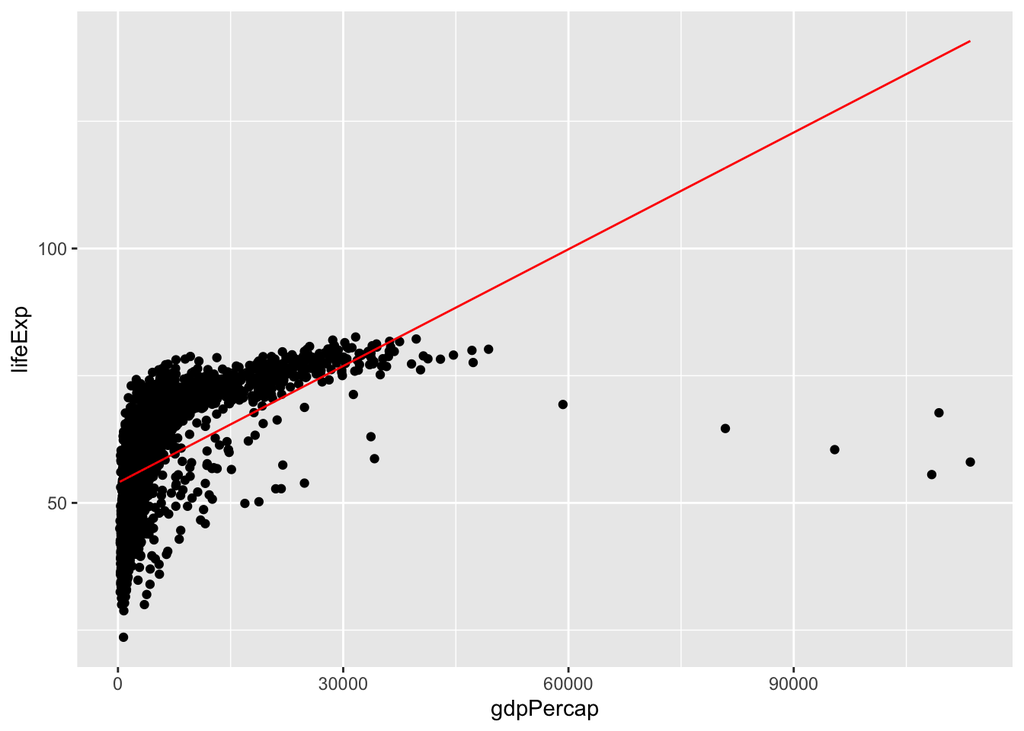

```r
lm(lifeExp ~ gdpPercap, data = df) %>%
  augment() %>%
  ggplot(aes(x = gdpPercap, y = lifeExp)) +
  geom_point() +
  geom_line(aes(x = gdpPercap, y = .fitted), color = "red") # +
```

```r
  # coord_trans(x = "log10", y = "log10")
```

pourquoi le fit est si mauvais? parce que les données contiennent une observation par pays **par an** et dans ce plot on ne tient pas en compte cela.

### régressions par groupe

On peut bien se demander: est-ce que le coefficient de la régression a varié au fil du temps? autrement dit: peut-être dans les années 50 il y avait une forte corrélation entre le PIB et l’augmentation de l’espérance de vie, mais cette corrélation est venue moins dans les années récentes.

Pour répondre à cela il faut faire une régression par an, et après regarder (plotter) les coefficients et leurs intervaux de confiance pour voir si l’effet est toujours bien vivant ou il s’affaiblit. De plus, le faire par continent aiderait. Peut-on faire cela?

Malheureusement, une approche simple et naive (groupez puis faites le lm) ne marche pas.

```r
df %>%
   group_by(continent, year) %>% # Marche pas
   # summarise(n = n())
   lm(lifeExp ~ gdpPercap, data = .)
```

```
##
## Call:
## lm(formula = lifeExp ~ gdpPercap, data = .)
##
## Coefficients:
## (Intercept)    gdpPercap
##   5.396e+01    7.649e-04
```

comment faire?

il faut passer par une foction specialisé par groupe, `group_modify()`. Il s’agit d’une espèce de `summarise()`, parce que `group_modify()` applique une fonction à chaque groupe. Mais alors que `summarise()` prend en argument une variable et ne peut retourner qu’une valuer unique par groupe (par exemple, la moyenne, le max, le min, la numerosité), `group_modify()` prend en argument une base de données et retourne une base de données de sortie par groupe.

On a donc `variable -> summarise() -> valeur unique` et `grouped_df -> group_modify() -> df`

```r
df %>%
   group_by(continent, year) %>%
   group_modify( ~ lm(lifeExp ~ gdpPercap, data = .) %>% tidy) -> reg_result

# df %>%
   # group_by(country) %>%
   # group_modify( ~ lm(lifeExp ~ gdpPercap, data = .) %>% tidy)
```

Si on regarde l’objet obtenu on peut voir qu’on obtient un objet qui contient sur chaque ligne un coefficient de l’estiamtion par group – ici année/continent.

On peut maintenant avec aise plotter les résultats et voir si notre idée que la rélation entre PIB et espérance de vie s’estompe avec le temps est soutenue par les données.

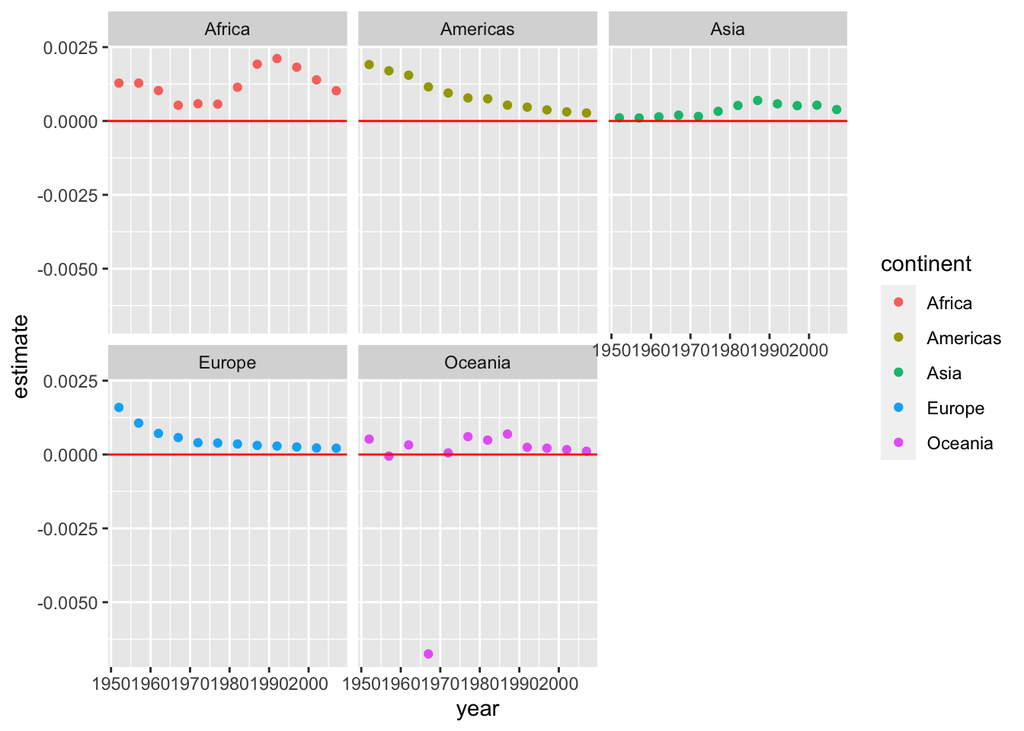

```r
reg_result %>%
  filter(term != "(Intercept)") %>%
  ggplot(aes(x = year, y = estimate, color = continent)) +
  geom_point() +
  facet_wrap(~ continent) +
  geom_hline(yintercept = 0, color = "red")
```

rappel: un point dans ce plot ne répresente pas les données mais une estimation de l’effet du PIB sur l’espérance de vie. L’intuition que la rélation soit moins forte au fil du temps tient bien la route pour l’Europe et les deux amériques; pas pour le reste du monde.

## sommaire de la méthode

1. groupez le data frame
2. `group_modify()`: on applique une fonction complexe (comme `lm`) à chaque groupe.
3. utiliser `tidy()` pour que les résultats du modèle soient en format data.frame; si ce n’est pas le cas, cela ne marchera pas.

### exercice

> faites une régression de pop sur year pour chaque continent – cela estime le taux de croissance moyen linéaire sur la période, par continent. Utilisez la méthode `group_modify()` décrite ci-dessus.

```r
df %>%
   group_by(continent, country) %>%
   group_modify(~ lm(pop ~ year, data = .) %>% tidy) -> reg_result
```

# Corrélation

On peut suivre la même démarche pour des corrélations. Une corrélation indique la présence d’une rélation linéaire entre les données. On va à nouveau utiliser le jeu de données `gapminder` et tester la corrélation entre PIB et lifeExp.

## Base R

une corrélation se fait simplement avec `cor()`.

```r
cor(df$lifeExp, df$gdpPercap)
```

```
## [1] 0.5837062
```

par contre si on veut tester la significativité statistique de cette corrélation il faut utiliser `cor.test()`:

```r
cor.test(df$lifeExp, df$gdpPercap) -> correlation
# cor.test(df$lifeExp, df$gdpPercap) %>% tidy()
```

notez que `cor()` retounre tout simplement une valeur; `cor_test()` retourne en revanche une liste, un objet complexe et avec plusieurs attributs, exactement comme `lm`.

## Tidyverse, juste corrélation

La syntaxe du tidyverse est assez simple parce qu’elle peut utiliser directement `summarise()`. Summarise marche avec toute fonction qui prend un vecteur et retourne un nombre.

```r
df %>%
  summarise(corr = cor(.$lifeExp, .$gdpPercap))
```

```
## # A tibble: 1 x 1
##    corr
##   <dbl>
## 1 0.584
```

```r
df %>%
  group_by(continent) %>%
  group_modify(~ cor(.$lifeExp, .$gdpPercap)%>% tidy())
```

```
## # A tibble: 5 x 2
## # Groups:   continent [5]
##   continent     x
##   <fct>     <dbl>
## 1 Africa    0.426
## 2 Americas  0.558
## 3 Asia      0.382
## 4 Europe    0.781
## 5 Oceania   0.956
```

group_by(), group_modify() et cor.test()

```r
df %>%
  group_by(continent) %>%
  group_modify(~ cor.test(.$lifeExp, .$gdpPercap)%>% tidy())
```

```
## # A tibble: 5 x 9
## # Groups:   continent [5]
##   continent estimate statistic  p.value parameter conf.low conf.high method
##   <fct>        <dbl>     <dbl>    <dbl>     <int>    <dbl>     <dbl> <chr>
## 1 Africa       0.426     11.7  7.60e-29       622    0.359     0.488 Pears…
## 2 Americas     0.558     11.6  5.45e-26       298    0.475     0.632 Pears…
## 3 Asia         0.382      8.21 3.29e-15       394    0.295     0.463 Pears…
## 4 Europe       0.781     23.6  4.05e-75       358    0.737     0.818 Pears…
## 5 Oceania      0.956     15.4  2.99e-13        22    0.901     0.981 Pears…
## # … with 1 more variable: alternative <chr>
```

La corrélation est bcp plus forte pour Europe et Océanie.

## tidyverse, corrélation et test

En revanche si on veut utiliser cor.test pour connaitre la valuer p de notre corrélation, on ne peut pas utiliser directement l’approche naïve – parce que `summarise()` ne sait pas quoi faire avec les nombreuses dimensions de l’objet retourné par la fonction `cor.test()`. L’approche naïve ne marche pas:

```r
# df %>%
  # group_by(continent) %>%
  # summarise(corr = cor.test(.$lifeExp, .$gdpPercap))
# Marche pas
```

et voilà, R râle parce que `summmarise()` s’attend à une seule valeur et en reçoit 9 (et chacune d’entre elles est un objet complexe).

Il faut à nouveau passer par `group_modify()`. Il suffit de changer le `lm` par un `cor.test`:

```r
df %>%
  group_by(continent) %>%
  group_modify(~ cor.test(.$lifeExp, .$gdpPercap) %>% tidy())
```

```
## # A tibble: 5 x 9
## # Groups:   continent [5]
##   continent estimate statistic  p.value parameter conf.low conf.high method
##   <fct>        <dbl>     <dbl>    <dbl>     <int>    <dbl>     <dbl> <chr>
## 1 Africa       0.426     11.7  7.60e-29       622    0.359     0.488 Pears…
## 2 Americas     0.558     11.6  5.45e-26       298    0.475     0.632 Pears…
## 3 Asia         0.382      8.21 3.29e-15       394    0.295     0.463 Pears…
## 4 Europe       0.781     23.6  4.05e-75       358    0.737     0.818 Pears…
## 5 Oceania      0.956     15.4  2.99e-13        22    0.901     0.981 Pears…
## # … with 1 more variable: alternative <chr>
```

et voilà, on a les estimations (elles sont les mêmes que toute à l’heure) mais aussi les valuers p et les intervals de confiance.

### Exercice

> calculez l’interval de confiance de la corrélation entre lifeExp et gdpPercap pour chaque continents pour chaque année. Plottez les résultats pour la France, le Japon et la Bolivie au fil du temps.

[output not shown]

[output cut: 124 more lines]

[output not shown]

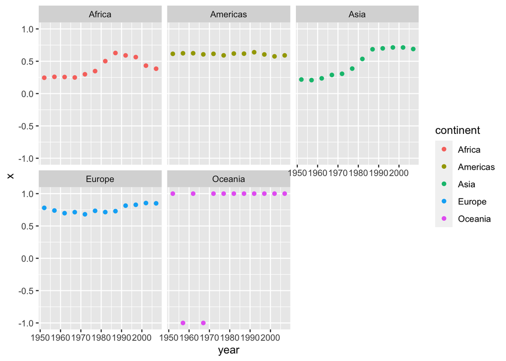

```r
# Strategie
# Grouper par country et year
# Appliquer group_modify() et cor.test() + tidy
# Filter les pays qu'il nous faut
# Faire le plot des intervalles de confiances
df %>%
  group_by(continent, year) %>%
  filter(is.na(lifeExp) == FALSE, is.na(gdpPercap) == FALSE) %>%
  group_modify(~ cor(.$lifeExp, .$gdpPercap) %>% tidy()) %>%
  ggplot(aes(x = year, y = x, color = continent)) +
  geom_point() +
  facet_wrap(~ continent)
```

# t-test (et n’importe quel autre test)

le test T à une variable sert à tester si la moyenne d’une variable est significativement différent d’une valeur de référence (par défaut: 0); à deux variables à tester si la moyenne d’une variable est statistiquement différente de l’autre.

1. peut on dire que l’espérance de vie à la naissance est > 60 dans le monde?

## Base R

```r
t.test(df$lifeExp > 60)
```

```
##
##  One Sample t-test
##
## data:  df$lifeExp > 60
## t = 42.497, df = 1703, p-value < 2.2e-16
## alternative hypothesis: true mean is not equal to 0
## 95 percent confidence interval:
##  0.4909176 0.5384251
## sample estimates:
## mean of x
## 0.5146714
```

```r
mean(df$lifeExp)
```

```
## [1] 59.47444
```

Mais peut-être que cet âge de 60 a été dépassé à des temps différents dans des pays différents.

Si on ne voulait qu’afficher l’âge moyen par continent et année, il suffit un appel à `summarise`:

```r
df %>%
  group_by(continent, year) %>%
  summarise(mean_lifeExp = mean(lifeExp))
```

```
## # A tibble: 60 x 3
## # Groups:   continent [5]
##    continent  year mean_lifeExp
##    <fct>     <int>        <dbl>
##  1 Africa     1952         39.1
##  2 Africa     1957         41.3
##  3 Africa     1962         43.3
##  4 Africa     1967         45.3
##  5 Africa     1972         47.5
##  6 Africa     1977         49.6
##  7 Africa     1982         51.6
##  8 Africa     1987         53.3
##  9 Africa     1992         53.6
## 10 Africa     1997         53.6
## # … with 50 more rows
```

mais si on veut tester la différence par rapport à 60 avec in test T il faut passer par un `group_modify()`, comme on a vu pour le `lm` et la `cor`relation:

```r
## code dans une seule pipe
df %>%
  group_by(continent, year) %>%
  group_modify(~ t.test(.$lifeExp) %>% tidy)
```

```
## # A tibble: 60 x 10
## # Groups:   continent, year [60]
##    continent  year estimate statistic  p.value parameter conf.low conf.high
##    <fct>     <int>    <dbl>     <dbl>    <dbl>     <dbl>    <dbl>     <dbl>
##  1 Africa     1952     39.1      54.8 5.44e-47        51     37.7      40.6
##  2 Africa     1957     41.3      52.9 3.00e-46        51     39.7      42.8
##  3 Africa     1962     43.3      53.2 2.44e-46        51     41.7      45.0
##  4 Africa     1967     45.3      53.7 1.42e-46        51     43.6      47.0
##  5 Africa     1972     47.5      53.3 2.09e-46        51     45.7      49.2
##  6 Africa     1977     49.6      52.5 4.53e-46        51     47.7      51.5
##  7 Africa     1982     51.6      50.4 3.40e-45        51     49.5      53.6
##  8 Africa     1987     53.3      48.9 1.58e-44        51     51.2      55.5
##  9 Africa     1992     53.6      40.9 1.20e-40        51     51.0      56.3
## 10 Africa     1997     53.6      42.5 1.82e-41        51     51.1      56.1
## # … with 50 more rows, and 2 more variables: method <chr>, alternative <chr>
```

et avec un plot on obtient la réponse:

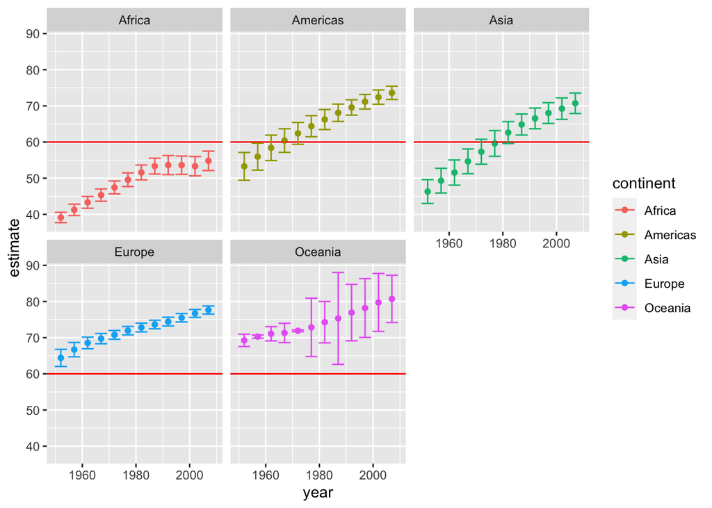

```r
df %>%
  group_by(continent, year) %>%
  group_modify(~ t.test(.$lifeExp) %>% tidy) %>%
  ggplot(aes(x = year, y = estimate, color = continent)) +
  facet_wrap(~ continent) +
  geom_point() +
  geom_hline(yintercept = 60, color = "red") +
  geom_errorbar(aes(xmin = year, xmax = year, ymin = conf.low, ymax = conf.high))
```

## Exercice sur le t.test

> est-ce que le dgp percapita est inferieur a 2000 euros/an par continent par annee?

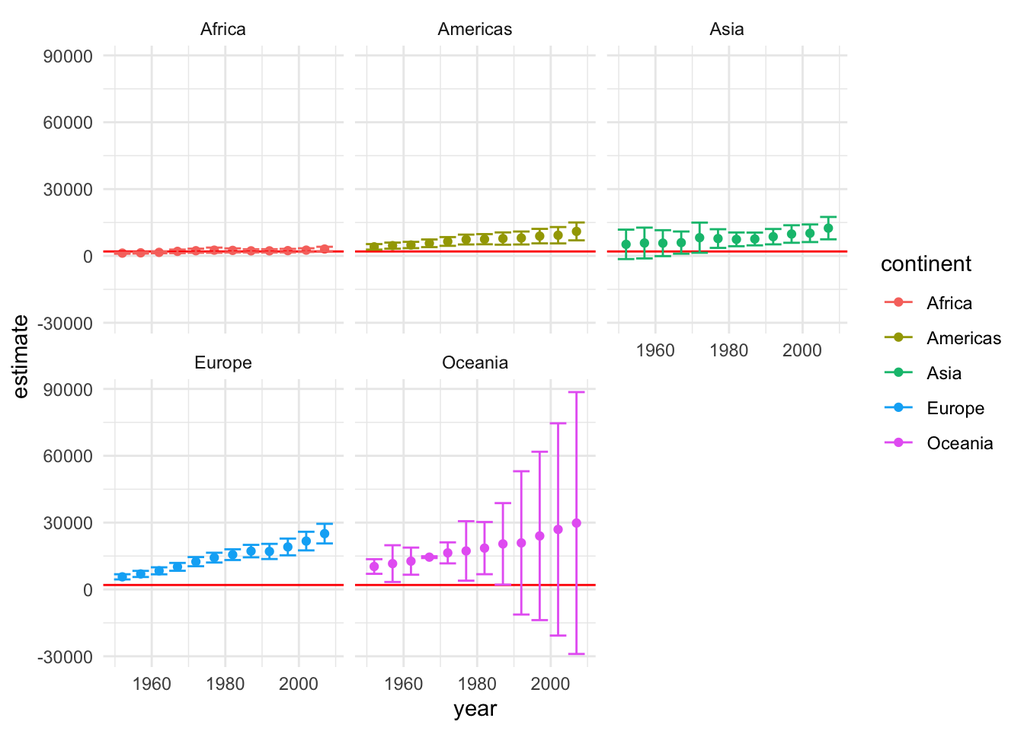

```r
# Strategie
# 1, group_by()
# 2, t.test(), group_modify() + tidy
## t.test(var, mu = K, alternative = "greater"/"smaller")
# 3, plot

df %>%
  group_by(continent, year) %>%
  group_modify(~ t.test(.$gdpPercap, mu = 2000) %>% tidy) %>%
  ggplot(aes(x = year, y = estimate, color = continent)) +
  facet_wrap(~ continent) +
  geom_point() +
  geom_hline(yintercept = 2000, color = "red") +
  geom_errorbar(aes(xmin = year, xmax = year, ymin = conf.low, ymax = conf.high)) +
  theme_minimal()
```

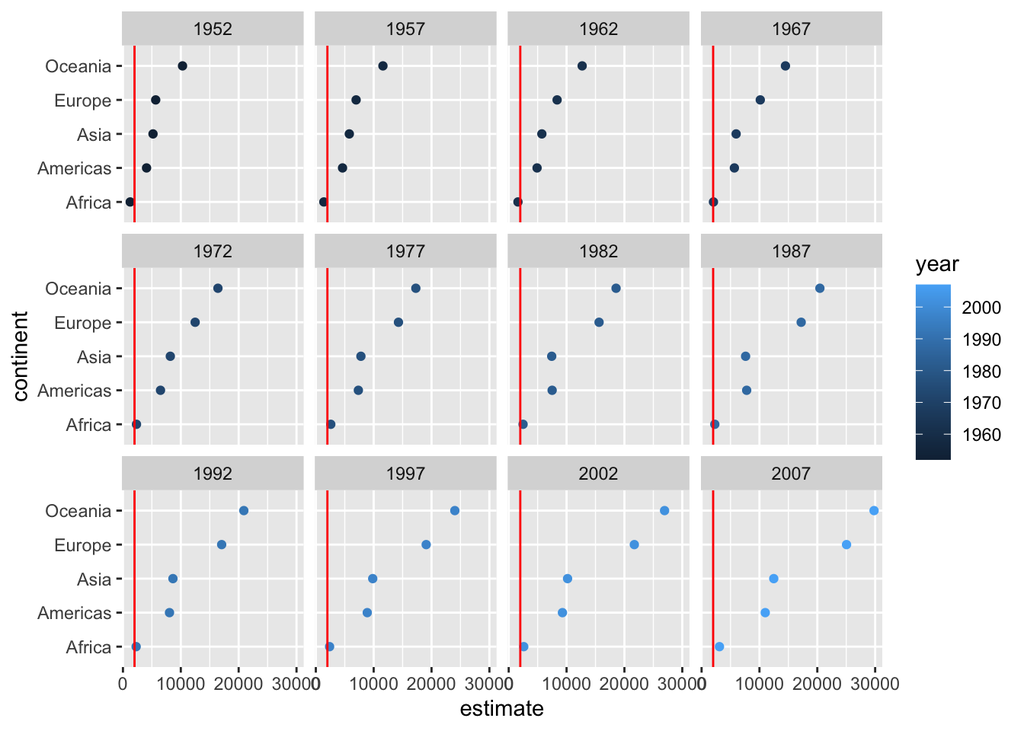

```r
df %>%
  # etape 1
  group_by(continent, year) %>%
  # etape 2
  group_modify(~ t.test(.$gdpPercap, mu = 2000) %>% tidy) %>%
  # etape 3
  ggplot(aes(x = continent, y = estimate, color = year)) +
  facet_wrap(~ year) +
  geom_point() +
  geom_hline(yintercept = 2000, color = "red") +
  coord_flip()
```

```r
# t.test(df$gdpPercap, mu = 2000, alternative = "less")
```